# Bevan Joubert

## Project 6 - Neural Networks

```python
# Import the required packages.
# Standard Packages
import numpy as np
import pandas as pd
import matplotlib.pyplot as plt
import seaborn as sns
# Data preparation.
from sklearn.model_selection import train_test_split
from sklearn.preprocessing import StandardScaler
# Trnsorflow and Keras
import tensorflow as tf
from tensorflow.keras.models import Sequential
from tensorflow.keras.layers import Dense, Dropout, BatchNormalization
from tensorflow.keras import optimizers
# Performance Metrics
from sklearn.metrics import accuracy_score, confusion_matrix, precision_score, recall_score, f1_score, precision_recall_curve, auc
# Do some formatting of the page.
from IPython.core.interactiveshell import InteractiveShell
pd.options.display.float_format = '{:,.2f}'.format
from IPython.core.display import display, HTML
display(HTML("<style>.container { width:90% !important; }</style>"))
pd.set_option('display.max_columns', None)
pd.set_option('display.float_format', '{:0.4f}'.format)
```

```python
# Import the dataset.
bankData = pd.read_csv('bank.csv')
bankData.head(10)
```

|  | RowNumber | CustomerId | Surname | CreditScore | Geography | Gender | Age | Tenure | Balance | NumOfProducts | HasCrCard | IsActiveMember | EstimatedSalary | Exited |
| --- | --- | --- | --- | --- | --- | --- | --- | --- | --- | --- | --- | --- | --- | --- |
| 0 | 1 | 15634602 | Hargrave | 619 | France | Female | 42 | 2 | 0.0000 | 1 | 1 | 1 | 101348.8800 | 1 |
| 1 | 2 | 15647311 | Hill | 608 | Spain | Female | 41 | 1 | 83807.8600 | 1 | 0 | 1 | 112542.5800 | 0 |
| 2 | 3 | 15619304 | Onio | 502 | France | Female | 42 | 8 | 159660.8000 | 3 | 1 | 0 | 113931.5700 | 1 |
| 3 | 4 | 15701354 | Boni | 699 | France | Female | 39 | 1 | 0.0000 | 2 | 0 | 0 | 93826.6300 | 0 |
| 4 | 5 | 15737888 | Mitchell | 850 | Spain | Female | 43 | 2 | 125510.8200 | 1 | 1 | 1 | 79084.1000 | 0 |
| 5 | 6 | 15574012 | Chu | 645 | Spain | Male | 44 | 8 | 113755.7800 | 2 | 1 | 0 | 149756.7100 | 1 |
| 6 | 7 | 15592531 | Bartlett | 822 | France | Male | 50 | 7 | 0.0000 | 2 | 1 | 1 | 10062.8000 | 0 |
| 7 | 8 | 15656148 | Obinna | 376 | Germany | Female | 29 | 4 | 115046.7400 | 4 | 1 | 0 | 119346.8800 | 1 |
| 8 | 9 | 15792365 | He | 501 | France | Male | 44 | 4 | 142051.0700 | 2 | 0 | 1 | 74940.5000 | 0 |
| 9 | 10 | 15592389 | H? | 684 | France | Male | 27 | 2 | 134603.8800 | 1 | 1 | 1 | 71725.7300 | 0 |

```python
bankData.shape
```

```
(10000, 14)
```

### Univariate Analysis

```python
bankData.info()
```

```
<class 'pandas.core.frame.DataFrame'>
RangeIndex: 10000 entries, 0 to 9999
Data columns (total 14 columns):
 #   Column           Non-Null Count  Dtype
---  ------           --------------  -----
 0   RowNumber        10000 non-null  int64
 1   CustomerId       10000 non-null  int64
 2   Surname          10000 non-null  object
 3   CreditScore      10000 non-null  int64
 4   Geography        10000 non-null  object
 5   Gender           10000 non-null  object
 6   Age              10000 non-null  int64
 7   Tenure           10000 non-null  int64
 8   Balance          10000 non-null  float64
 9   NumOfProducts    10000 non-null  int64
 10  HasCrCard        10000 non-null  int64
 11  IsActiveMember   10000 non-null  int64
 12  EstimatedSalary  10000 non-null  float64
 13  Exited           10000 non-null  int64
dtypes: float64(2), int64(9), object(3)
memory usage: 1.1+ MB
```

```python
# There are no null values, however, some of the surnames seem to be incomplete. Such as "H?" in RowNumber 10. This is not a problem as these will be dropped.
# All datatypes are as expected. Therefore, there are no numerical values which have been replaced by characters, this would result in a datatype of object for the corresponding column.
```

```python
# Check how many records contain 0 values for each of the columns.
bankData.isin([0]).sum()
```

```
RowNumber             0
CustomerId            0
Surname               0
CreditScore           0
Geography             0
Gender                0
Age                   0
Tenure              413
Balance            3617
NumOfProducts         0
HasCrCard          2945
IsActiveMember     4849
EstimatedSalary       0
Exited             7963
dtype: int64
```

```python
# All customers have a tleast one product, despite the fact that almost half are labelled is not being active members.
# All customers have a form of income.
# All the 0 values are in columns where 0 values can be expected.
# This dataset could be vulnerable to learning bias since the outcome is quite unbalanced. Only about 20% churn.
```

```python
# Check the number of unique values for each column.
bankData.nunique()
```

```
RowNumber          10000
CustomerId         10000
Surname             2932
CreditScore          460
Geography              3
Gender                 2
Age                   70
Tenure                11
Balance             6382
NumOfProducts          4
HasCrCard              2
IsActiveMember         2
EstimatedSalary     9999
Exited                 2
dtype: int64
```

```python
# RowNumber and CustomerID are all unique, as they should be.
# There are customers from only 3 different countries.
# There seems to be quite a large age distribution.
```

```python
# Display the 5 number summary of all the features.
bankData.describe().transpose()
```

|  | count | mean | std | min | 25% | 50% | 75% | max |
| --- | --- | --- | --- | --- | --- | --- | --- | --- |
| RowNumber | 10000.0000 | 5000.5000 | 2886.8957 | 1.0000 | 2500.7500 | 5000.5000 | 7500.2500 | 10000.0000 |
| CustomerId | 10000.0000 | 15690940.5694 | 71936.1861 | 15565701.0000 | 15628528.2500 | 15690738.0000 | 15753233.7500 | 15815690.0000 |
| CreditScore | 10000.0000 | 650.5288 | 96.6533 | 350.0000 | 584.0000 | 652.0000 | 718.0000 | 850.0000 |
| Age | 10000.0000 | 38.9218 | 10.4878 | 18.0000 | 32.0000 | 37.0000 | 44.0000 | 92.0000 |
| Tenure | 10000.0000 | 5.0128 | 2.8922 | 0.0000 | 3.0000 | 5.0000 | 7.0000 | 10.0000 |
| Balance | 10000.0000 | 76485.8893 | 62397.4052 | 0.0000 | 0.0000 | 97198.5400 | 127644.2400 | 250898.0900 |
| NumOfProducts | 10000.0000 | 1.5302 | 0.5817 | 1.0000 | 1.0000 | 1.0000 | 2.0000 | 4.0000 |
| HasCrCard | 10000.0000 | 0.7055 | 0.4558 | 0.0000 | 0.0000 | 1.0000 | 1.0000 | 1.0000 |
| IsActiveMember | 10000.0000 | 0.5151 | 0.4998 | 0.0000 | 0.0000 | 1.0000 | 1.0000 | 1.0000 |
| EstimatedSalary | 10000.0000 | 100090.2399 | 57510.4928 | 11.5800 | 51002.1100 | 100193.9150 | 149388.2475 | 199992.4800 |
| Exited | 10000.0000 | 0.2037 | 0.4028 | 0.0000 | 0.0000 | 0.0000 | 0.0000 | 1.0000 |

```python
# Look at the skewness of the numerical features.
bankData.skew()
```

```
RowNumber          0.0000
CustomerId         0.0011
CreditScore       -0.0716
Age                1.0113
Tenure             0.0110
Balance           -0.1411
NumOfProducts      0.7456
HasCrCard         -0.9018
IsActiveMember    -0.0604
EstimatedSalary    0.0021
Exited             1.4716
dtype: float64
```

```python
# Only skewness of CreditScore, Age, Tenure, Balance, NumOfProducts and EstimatedSalary should be looked at.
# Skewness is quite low overall, there is nothing of major concern.
```

```python
bankData.head()
```

|  | RowNumber | CustomerId | Surname | CreditScore | Geography | Gender | Age | Tenure | Balance | NumOfProducts | HasCrCard | IsActiveMember | EstimatedSalary | Exited |
| --- | --- | --- | --- | --- | --- | --- | --- | --- | --- | --- | --- | --- | --- | --- |
| 0 | 1 | 15634602 | Hargrave | 619 | France | Female | 42 | 2 | 0.0000 | 1 | 1 | 1 | 101348.8800 | 1 |
| 1 | 2 | 15647311 | Hill | 608 | Spain | Female | 41 | 1 | 83807.8600 | 1 | 0 | 1 | 112542.5800 | 0 |
| 2 | 3 | 15619304 | Onio | 502 | France | Female | 42 | 8 | 159660.8000 | 3 | 1 | 0 | 113931.5700 | 1 |
| 3 | 4 | 15701354 | Boni | 699 | France | Female | 39 | 1 | 0.0000 | 2 | 0 | 0 | 93826.6300 | 0 |
| 4 | 5 | 15737888 | Mitchell | 850 | Spain | Female | 43 | 2 | 125510.8200 | 1 | 1 | 1 | 79084.1000 | 0 |

```
        Geography
France       5014
Germany      2509
Spain        2477
```

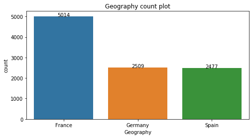

```
       Gender
Male     5457
Female   4543
```

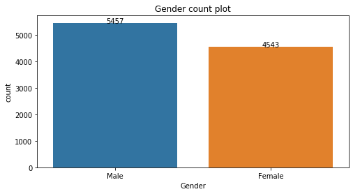

```
  NumOfProducts
1          5084
2          4590
3           266
4            60
```

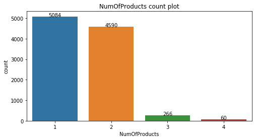

```
    HasCrCard
yes      7055
no       2945
```

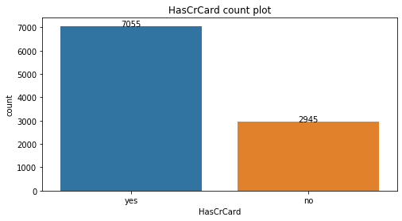

```
    IsActiveMember
yes           5151
no            4849
```

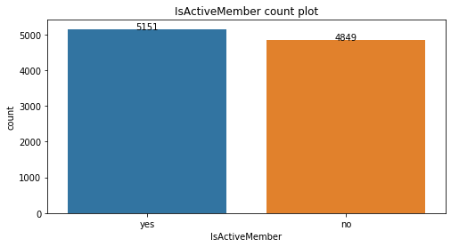

```
    Exited
no    7963
yes   2037
```

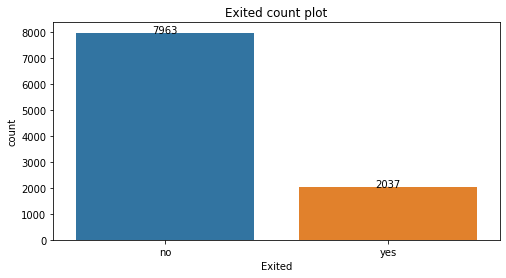

```python
# Show the value counts for some of the categorical features.
categoricalColumns = ['Geography', 'Gender', 'NumOfProducts', 'HasCrCard', 'IsActiveMember', 'Exited']
for column in categoricalColumns:
    temp_df = pd.DataFrame(bankData[column].value_counts().sort_values(ascending=False))
    temp_df[column] = temp_df[column].astype(object)
    if(column is 'HasCrCard' or column is 'IsActiveMember' or column is 'Exited'):
        temp_df.index = pd.Series(temp_df.index.to_list()).map({0:'no', 1:'yes'})
    print(temp_df)
    plt.figure(figsize=(8,4))
    ax0 = sns.barplot(x=temp_df.index, y=temp_df[column])
    ax0.set_title(str(column) + " count plot")
    ax0.set_xlabel(column)
    ax0.set_ylabel("count")
    count=0
    for index, row in temp_df.iterrows():
        ax0.text(count, row[column], row[column], color='black', ha="center")
        count +=  1
    plt.show()
```

```python
bankData.head()
```

|  | RowNumber | CustomerId | Surname | CreditScore | Geography | Gender | Age | Tenure | Balance | NumOfProducts | HasCrCard | IsActiveMember | EstimatedSalary | Exited |
| --- | --- | --- | --- | --- | --- | --- | --- | --- | --- | --- | --- | --- | --- | --- |
| 0 | 1 | 15634602 | Hargrave | 619 | France | Female | 42 | 2 | 0.0000 | 1 | 1 | 1 | 101348.8800 | 1 |
| 1 | 2 | 15647311 | Hill | 608 | Spain | Female | 41 | 1 | 83807.8600 | 1 | 0 | 1 | 112542.5800 | 0 |
| 2 | 3 | 15619304 | Onio | 502 | France | Female | 42 | 8 | 159660.8000 | 3 | 1 | 0 | 113931.5700 | 1 |
| 3 | 4 | 15701354 | Boni | 699 | France | Female | 39 | 1 | 0.0000 | 2 | 0 | 0 | 93826.6300 | 0 |
| 4 | 5 | 15737888 | Mitchell | 850 | Spain | Female | 43 | 2 | 125510.8200 | 1 | 1 | 1 | 79084.1000 | 0 |

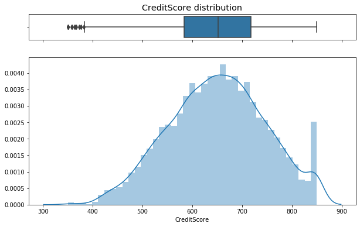

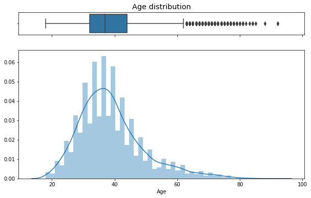

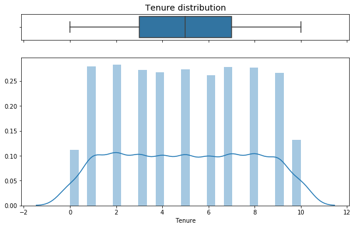

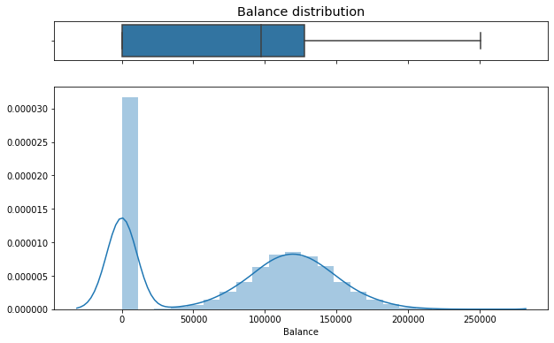

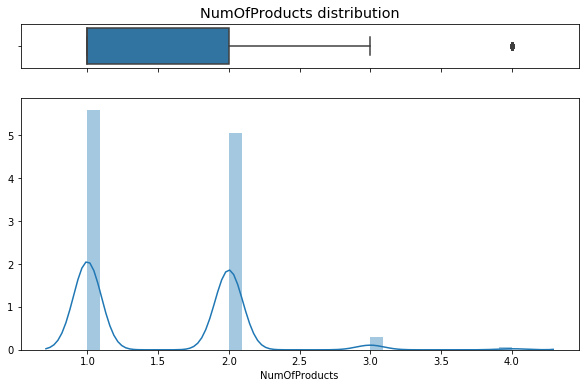

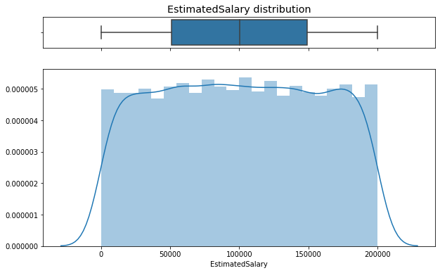

```python
# Look at the distributions of the numerical data in the form of boxplots and histograms.
numericalColumns = ['CreditScore', 'Age', 'Tenure', 'Balance', 'NumOfProducts', 'EstimatedSalary']
for column in numericalColumns:
    # Cut the window in 2 parts
    f, (ax_box, ax_hist) = plt.subplots(2, sharex=True, gridspec_kw={"height_ratios": (.15, .85)}, figsize=(10,6))
    ax_box.set_title(column + " distribution", size='x-large')
    # Add a graph in each part
    sns.boxplot(bankData[column], ax=ax_box)
    sns.distplot(bankData[column], ax=ax_hist)

    # Remove x axis name for the boxplot
    ax_box.set(xlabel='')
```

```python
# The Age distribution has the most outliers, it is quite normally distributed, but is slightly right skewed.
# Maybe Age can be binned into categories, such as 0-30, 31-50, 50+.
# CreditScore is reasonably normal, except for an unusually large number of 850 values.
# It seems that 850 is the maximum credit score one can have and therefore many people have that credit score.
# Balance is quite normally distributed, except for a large number of 0 balances. It might be worth checking the relationship between 0 balance and churn.
```

### Bivariate Analysis

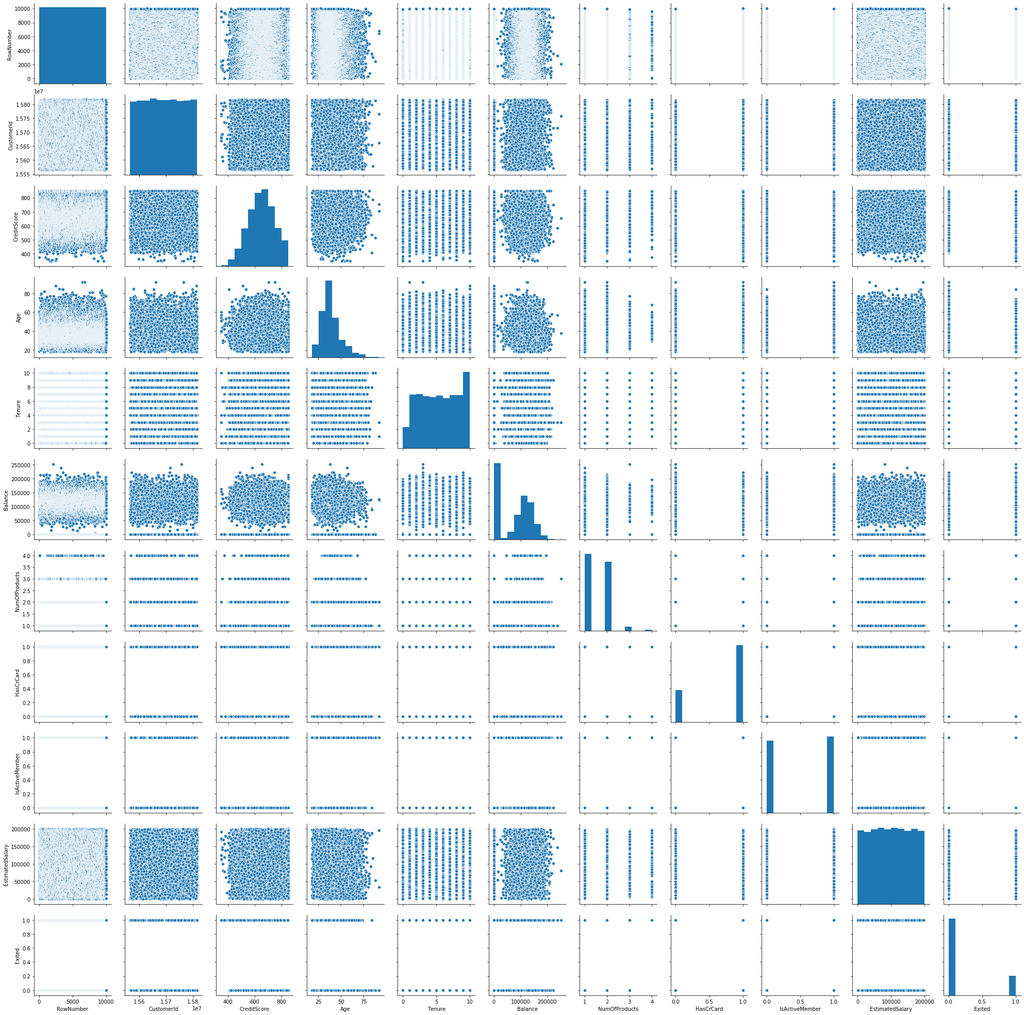

```python
# Have a look at the pariplot for the dataset.
sns.pairplot(bankData)
```

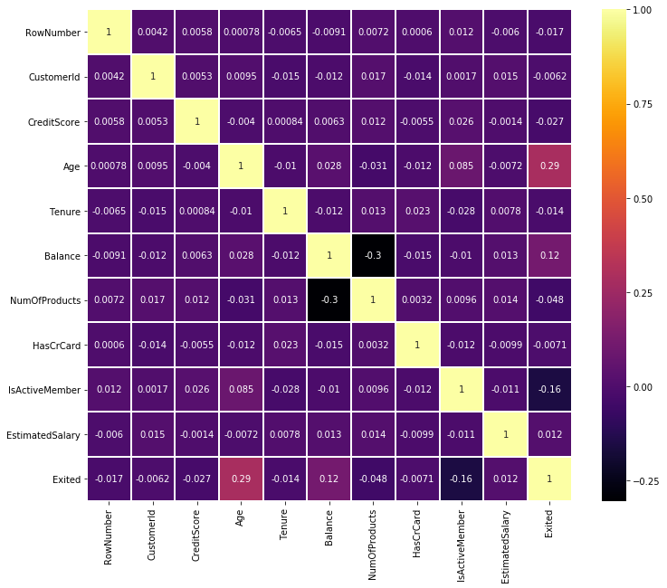

```python
# From the pariplot there does not seem to be much correlation between features, confirm this wwith a correlation heatmap.
# Represent the correlation visually.
plt.figure(figsize=(12,10))
sns.heatmap(bankData.corr(), annot=True, linewidth=1, cmap='inferno')
```

```python
# There is very little correlation between features.
# If comparing the highest correlations, 0.29 and -0.3, to the corresponding figures on the pairplot, it seems that even these correlation values are mere coincidence.
```

### Data Preparation

```python
# Create a new dataset to apply the alterations to.
bankData_p = bankData.copy() # _p suffix for prepared.

# Drop the RowNumber, CustomerId and Surname features.
dropList = ['RowNumber', 'CustomerId', 'Surname']
bankData_p.drop(dropList, axis='columns', inplace=True)
```

```python
# One-hot encode the Geography and Gender columns.
bankData_p = pd.get_dummies(bankData_p, drop_first=True)
```

```python
# Have a look at the new dataset.
bankData_p.head()
```

|  | CreditScore | Age | Tenure | Balance | NumOfProducts | HasCrCard | IsActiveMember | EstimatedSalary | Exited | Geography_Germany | Geography_Spain | Gender_Male |
| --- | --- | --- | --- | --- | --- | --- | --- | --- | --- | --- | --- | --- |
| 0 | 619 | 42 | 2 | 0.0000 | 1 | 1 | 1 | 101348.8800 | 1 | 0 | 0 | 0 |
| 1 | 608 | 41 | 1 | 83807.8600 | 1 | 0 | 1 | 112542.5800 | 0 | 0 | 1 | 0 |
| 2 | 502 | 42 | 8 | 159660.8000 | 3 | 1 | 0 | 113931.5700 | 1 | 0 | 0 | 0 |
| 3 | 699 | 39 | 1 | 0.0000 | 2 | 0 | 0 | 93826.6300 | 0 | 0 | 0 | 0 |
| 4 | 850 | 43 | 2 | 125510.8200 | 1 | 1 | 1 | 79084.1000 | 0 | 0 | 1 | 0 |

```python
# Split the dataset into X and Y varaibles.
X = bankData_p.drop('Exited', axis='columns')
y = bankData_p['Exited']
```

```python
# Split the data into testing and training groups.
X_train, X_test, y_train, y_test = train_test_split(X, y, test_size=0.3, random_state=9, stratify=y)
print(X_train.shape)
print(y_train.shape)
print(X_test.shape)
print(y_test.shape)
```

```
(7000, 11)
(7000,)
(3000, 11)
(3000,)
```

```python
# The one-hot columns should not be scaled, but the numerical columns should, seperate the training and testing data between the two types.
scaleColumns = ['CreditScore', 'Age', 'Tenure', 'Balance', 'NumOfProducts', 'EstimatedSalary']
oneHotColumns = ['HasCrCard', 'IsActiveMember', 'Geography_Germany', 'Geography_Spain', 'Gender_Male']
X_train_scale = X_train[scaleColumns]
X_train_oneHot = X_train[oneHotColumns]
```

```python
X_train_scale.head()
```

|  | CreditScore | Age | Tenure | Balance | NumOfProducts | EstimatedSalary |
| --- | --- | --- | --- | --- | --- | --- |
| 7707 | 848 | 35 | 5 | 120046.7400 | 2 | 84710.6500 |
| 2977 | 505 | 45 | 9 | 131355.3000 | 3 | 195395.3300 |
| 9097 | 728 | 43 | 7 | 0.0000 | 2 | 40023.7000 |
| 5803 | 526 | 38 | 2 | 0.0000 | 2 | 58010.9800 |
| 1201 | 399 | 46 | 2 | 127655.2200 | 1 | 139994.6800 |

```python
X_train_oneHot.head()
```

|  | HasCrCard | IsActiveMember | Geography_Germany | Geography_Spain | Gender_Male |
| --- | --- | --- | --- | --- | --- |
| 7707 | 1 | 0 | 0 | 1 | 1 |
| 2977 | 1 | 0 | 0 | 1 | 0 |
| 9097 | 1 | 0 | 0 | 0 | 1 |
| 5803 | 0 | 0 | 0 | 1 | 1 |
| 1201 | 1 | 0 | 1 | 0 | 1 |

```python
# Also Seperate the test X dataset.
X_test_scale = X_test[scaleColumns]
X_test_oneHot = X_test[oneHotColumns]
```

```python
# Now scale the relevant parts of the dataset and concatenate the scaled and one-hot columns.
# Standardise the training and testing X data.
scaler = StandardScaler().fit(X_train_scale)

# Scale the training set.
X_train_scale = scaler.transform(X_train_scale)
# Concatenate the training set.
X_train = np.concatenate([X_train_scale, X_train_oneHot], axis=1)

# Scale the test set.
X_test_scale = scaler.transform(X_test_scale)
# Concatenate the test set.
X_test = np.concatenate([X_test_scale, X_test_oneHot], axis=1)
```

```python
# View the new training dataset.
pd.DataFrame(X_train).head()
```

|  | 0 | 1 | 2 | 3 | 4 | 5 | 6 | 7 | 8 | 9 | 10 |
| --- | --- | --- | --- | --- | --- | --- | --- | --- | --- | --- | --- |
| 0 | 2.0471 | -0.3706 | 0.0022 | 0.6885 | 0.8094 | -0.2589 | 1.0000 | 0.0000 | 0.0000 | 1.0000 | 1.0000 |
| 1 | -1.5108 | 0.5806 | 1.3863 | 0.8701 | 2.5340 | 1.6623 | 1.0000 | 0.0000 | 0.0000 | 1.0000 | 0.0000 |
| 2 | 0.8024 | 0.3903 | 0.6942 | -1.2389 | 0.8094 | -1.0346 | 1.0000 | 0.0000 | 0.0000 | 0.0000 | 1.0000 |
| 3 | -1.2929 | -0.0852 | -1.0359 | -1.2389 | 0.8094 | -0.7224 | 0.0000 | 0.0000 | 0.0000 | 1.0000 | 1.0000 |
| 4 | -2.6103 | 0.6757 | -1.0359 | 0.8107 | -0.9153 | 0.7007 | 1.0000 | 0.0000 | 1.0000 | 0.0000 | 1.0000 |

```python
# View the new testing dataset.
pd.DataFrame(X_test).head()
```

|  | 0 | 1 | 2 | 3 | 4 | 5 | 6 | 7 | 8 | 9 | 10 |
| --- | --- | --- | --- | --- | --- | --- | --- | --- | --- | --- | --- |
| 0 | -1.6352 | -0.7511 | -0.6899 | -1.2389 | -0.9153 | 1.3355 | 1.0000 | 1.0000 | 0.0000 | 0.0000 | 0.0000 |
| 1 | 0.9061 | 0.0099 | -1.3819 | 0.2773 | 0.8094 | 1.5588 | 0.0000 | 1.0000 | 0.0000 | 0.0000 | 0.0000 |
| 2 | -0.2868 | 0.8659 | 0.0022 | 0.6632 | -0.9153 | 1.0234 | 1.0000 | 1.0000 | 0.0000 | 0.0000 | 1.0000 |
| 3 | 0.0659 | -1.1315 | 1.0403 | -1.2389 | 0.8094 | -1.6171 | 0.0000 | 0.0000 | 0.0000 | 1.0000 | 0.0000 |
| 4 | 2.0263 | 2.1025 | -1.7280 | -1.2389 | 0.8094 | -0.0595 | 1.0000 | 1.0000 | 0.0000 | 1.0000 | 1.0000 |

### Neural Network Model

```python
# Initialise the model.
model = Sequential()
# Add the first hidden layer.
model.add(Dense(64, input_shape=(X_train.shape[1],), activation='relu'))
# Add a second hidden layer.
model.add(Dense(32, activation='tanh'))
# Add the output layer.
model.add(Dense(1, activation='sigmoid'))
```

```python
# Create an optimizer.
opt = optimizers.Adam()
```

```python
# Compile the model.
model.compile(optimizer=opt, loss='binary_crossentropy', metrics=['accuracy'])
```

```python
# View a summary of the model.
model.summary()
```

```
Model: "sequential"
_________________________________________________________________
Layer (type)                 Output Shape              Param #
=================================================================
dense (Dense)                (None, 64)                768
_________________________________________________________________
dense_1 (Dense)              (None, 32)                2080
_________________________________________________________________
dense_2 (Dense)              (None, 1)                 33
=================================================================
Total params: 2,881
Trainable params: 2,881
Non-trainable params: 0
_________________________________________________________________
```

```python
# Train the model.
model.fit(X_train, y_train.values, validation_data=(X_test, y_test.values), batch_size=500, epochs=10, verbose=1)
```

```
Train on 7000 samples, validate on 3000 samples
```

```
<tensorflow.python.keras.callbacks.History at 0x1eaa3ea9748>
```

```python
# Evaluate the model against the test data.
loss, accuracy = model.evaluate(X_test, y_test.values)
```

```python
print("Accuracy:\t{:.4f}".format(accuracy))
print("Loss:\t\t{:.4f}".format(loss))
```

```
Accuracy:	0.8383
Loss:		0.3926
```

### Performance Metrics

```python
y_trainPred = model.predict_classes(X_train)
y_testPred = model.predict_classes(X_test)
print("Training Accuracy:\t{:.4f}".format(accuracy_score(y_train, y_trainPred)))
print("Testing Accuracy:\t{:.4f}".format(accuracy_score(y_test, y_testPred)))
print('Recall:\t\t\t{:.4f}'.format(recall_score(y_test, y_testPred)))
print('Precision:\t\t{:.4f}'.format(precision_score(y_test, y_testPred)))
print('F1 Score:\t\t{:.4f}'.format(f1_score(y_test, y_testPred)))
```

```
Training Accuracy:	0.8327
Testing Accuracy:	0.8383
Recall:			0.3241
Precision:		0.7333
F1 Score:		0.4495
```

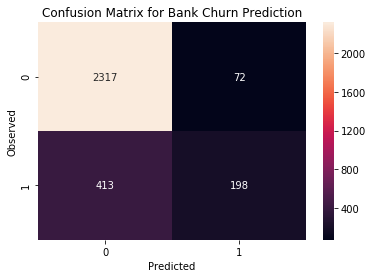

```python
cm=confusion_matrix(y_test, y_testPred)
sns.heatmap(cm, annot=True,  fmt='g', xticklabels = [0,1] , yticklabels = [0,1])
plt.title("Confusion Matrix for Bank Churn Prediction")
plt.ylabel('Observed')
plt.xlabel('Predicted')
plt.show()
```

#### Observations

- The model used the default Adam learning rate of 0.001.
- Thge model is quite well fitted since the training accuracy and the testing accuracy is very similar.
- I wouldn't say that 83% accuracy is great, we should try to get a better accuracy.
- The recall is especially poor at only ~32%.
- Recall is an important metric since false negatives mean that we will not be afforded an opportunity to try and prevent those people from churning.